# Principal Component Analysis

Dataset sediments.sand.red.scaled

This dataset contains 18 individuals and 5 variables, 1 qualitative variable is considered as illustrative.

### 1. Inertia distribution

The inertia of the first dimensions shows if there are strong relationships between variables and suggests the number of dimensions that should be studied.

The first two dimensions of PCA express **85.46%** of the total dataset inertia ; that means that 85.46% of the individuals (or variables) cloud total variability is explained by the plane. This percentage is high and thus the first plane represents an important part of the data variability. This value is greater than the reference value that equals **78.62%**, the variability explained by this plane is thus significant (the reference value is the 0.95-quantile of the inertia percentages distribution obtained by simulating 835 data tables of equivalent size on the basis of a normal distribution).

From these observations, it is probably not useful to interpret the next dimensions.

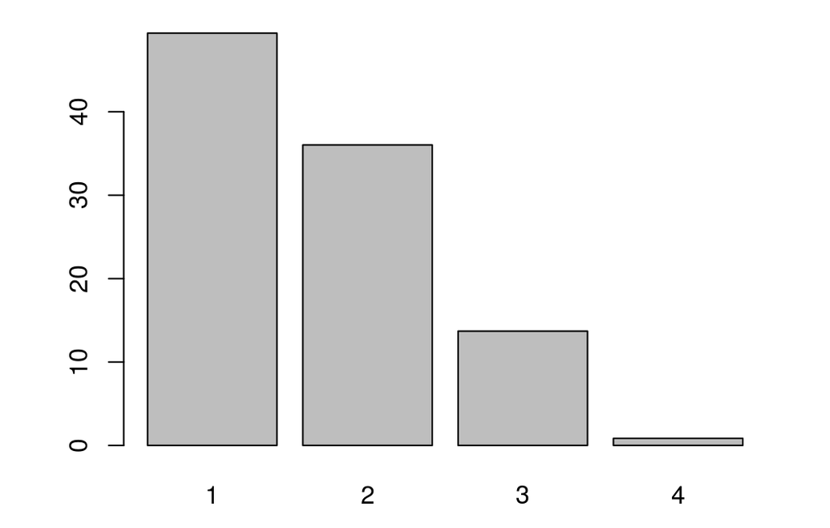

**Figure 1 - Decomposition of the total inertia on the components of the PCA**

An estimation of the right number of axis to interpret suggests to not interpret the analysis at all. Indeed, the amount of inertia of the first axis is not higher than that obtained by the 0.95-quantile of random distributions (49.43% against 52.03%). This observation suggests that no axis is carrying a real information. As a consequence, the description will stand to these axis.

### 2. Description of the dimension 1

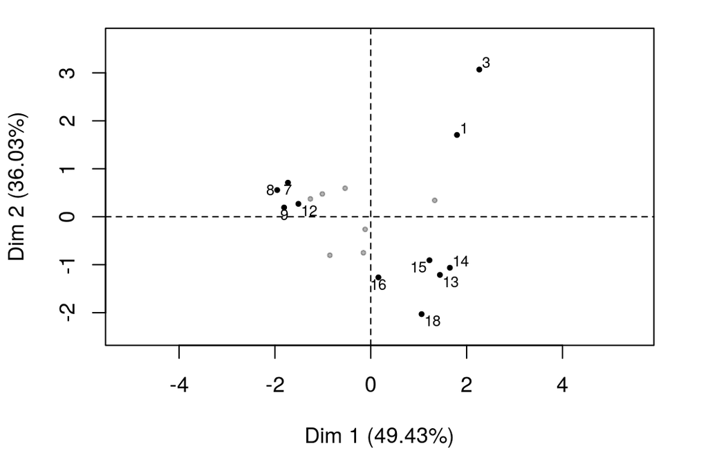

**Figure 2.1 - Individuals factor map (PCA)** *The labeled individuals are those with the higher contribution to the plane construction.*

The Wilks test p-value indicates which variable factors are the best separated on the plane (i.e. which one explain the best the distance between individuals).

```
##      station
## 9.874346e-08
```

There only is one possible qualitative variable to illustrate the distance between individuals : *station*.

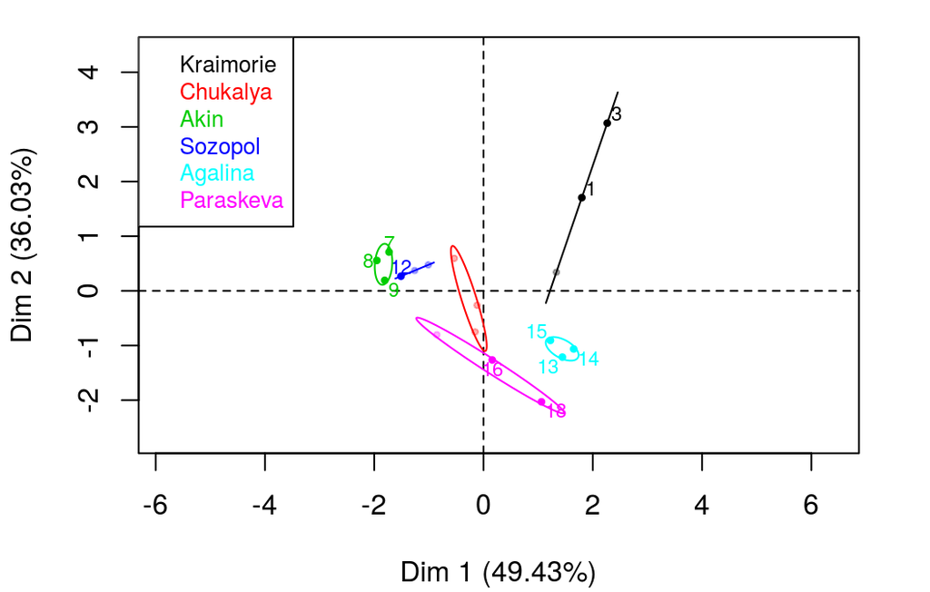

**Figure 2.2 - Individuals factor map (PCA)** *The labeled individuals are those with the higher contribution to the plane construction.* *The individuals are coloured after their category for the variable* station.

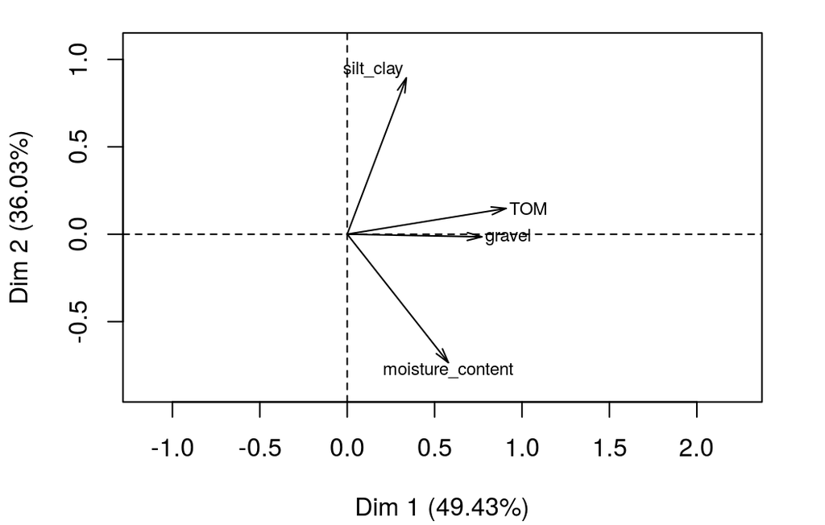

**Figure 2.3 - Variables factor map (PCA)** *The labeled variables are those the best shown on the plane.*

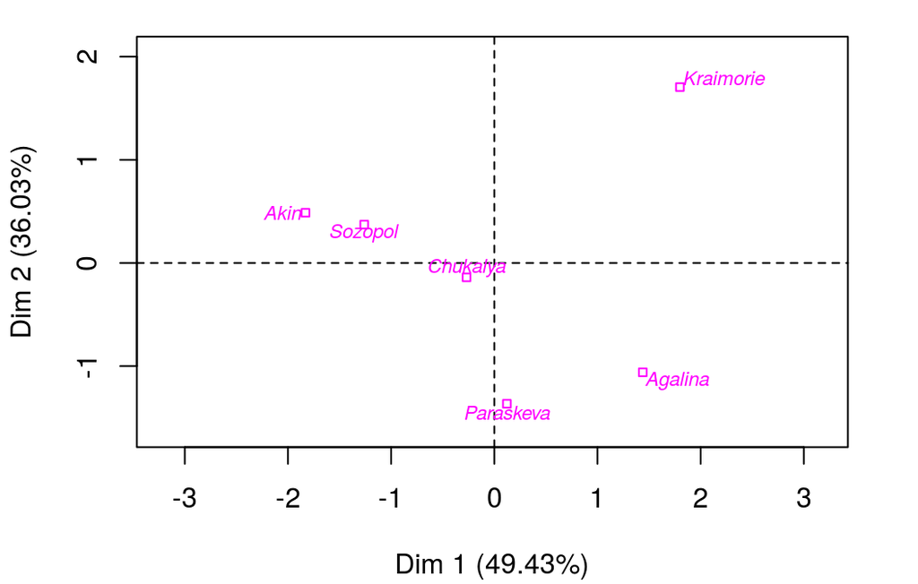

**Figure 2.4 - Qualitative factor map (PCA)** *The labeled factors are those the best shown on the plane.*

The **dimension 1** opposes individuals such as *1*, *3* and *14* (to the right of the graph, characterized by a strongly positive coordinate on the axis) to individuals such as *7*, *12*, *8* and *9* (to the left of the graph, characterized by a strongly negative coordinate on the axis).

The group in which the individual *14* stands (characterized by a positive coordinate on the axis) is sharing :

- high values for the variables *moisture_content* and *gravel* (variables are sorted from the strongest).

The group in which the individuals *1* and *3* stand (characterized by a positive coordinate on the axis) is sharing :

- high values for the variables *silt_clay* and *TOM* (variables are sorted from the strongest).

The group in which the individuals *7*, *12*, *8* and *9* stand (characterized by a negative coordinate on the axis) is sharing :

- low values for the variables *gravel*, *TOM* and *moisture_content* (variables are sorted from the weakest).

The group in which the individuals *1* and *3* stand (characterized by a positive coordinate on the axis) is sharing :

- high values for the variables *silt_clay* and *TOM* (variables are sorted from the strongest).

- high values for the variables *moisture_content* and *gravel* (variables are sorted from the strongest).

### 4. Classification

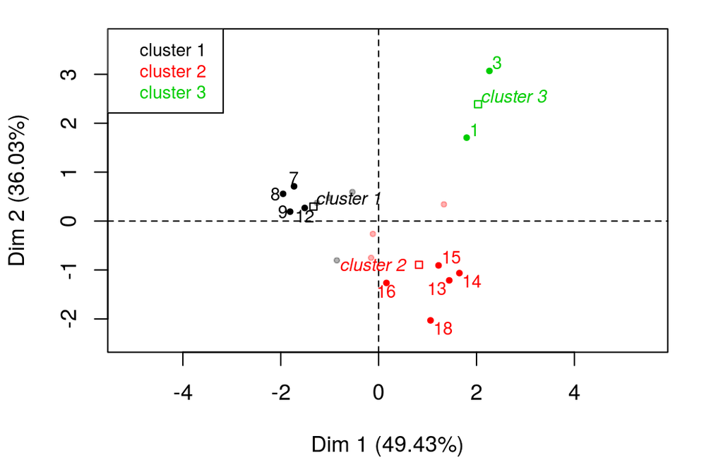

**Figure 4 - Ascending Hierarchical Classification of the individuals.** *The classification made on individuals reveals 3 clusters.*

The **cluster 1** is made of individuals such as *7*, *8*, *9* and *12*. This group is characterized by :

- low values for the variables *TOM*, *moisture_content* and *gravel* (variables are sorted from the weakest).

The **cluster 2** is made of individuals such as *13*, *14*, *15*, *16* and *18*. This group is characterized by :

- high values for the variables *moisture_content* and *gravel* (variables are sorted from the strongest).

The **cluster 3** is made of individuals such as *1* and *3*. This group is characterized by :

- high values for the variables *silt_clay* and *TOM* (variables are sorted from the strongest).

## Annexes

```r
dimdesc(res, axes = 1:0)
```

```
$Dim.1
$Dim.1$quanti
                 correlation      p.value
TOM                0.9347574 1.343490e-08
gravel             0.7923829 8.837638e-05
moisture_content   0.5952979 9.149646e-03

$Dim.1$quali
               R2      p.value
station 0.9221452 2.944183e-06

$Dim.1$category
           Estimate     p.value
Kraimorie  1.798885 0.010158652
Agalina    1.438990 0.048540756
Akin      -1.829947 0.008635272


$<NA>
$<NA>$quanti
                 correlation      p.value
moisture_content   0.5572325 0.0162869061
silt_clay         -0.7157834 0.0008365246
```

**Figure 5 - List of variables characterizing the dimensions of the analysis.**

```r
res.hcpc$desc.var
```

```
Link between the cluster variable and the categorical variables (chi-square test)
=================================================================================
           p.value df
station 0.01275047 10

Description of each cluster by the categories
=============================================
$`1`
NULL

$`2`
NULL

$`3`
                   Cla/Mod Mod/Cla   Global    p.value   v.test
station=Kraimorie 66.66667     100 16.66667 0.01960784 2.333769


Link between the cluster variable and the quantitative variables
================================================================
                      Eta2      P-value
TOM              0.8151882 3.165727e-06
silt_clay        0.7984112 6.074323e-06
moisture_content 0.6727853 2.297452e-04
gravel           0.4745047 8.021694e-03

Description of each cluster by quantitative variables
=====================================================
$`1`
                    v.test Mean in category  Overall mean sd in category
gravel           -2.833204       -0.7466148  4.009139e-17      0.1877147
moisture_content -2.887402       -0.7608972  9.714451e-17      0.4882999
TOM              -3.209470       -0.8457696 -1.881211e-16      0.3140682
                 Overall sd     p.value
gravel            0.9718253 0.004608400
moisture_content  0.9718253 0.003884376
TOM               0.9718253 0.001329800

$`2`
                   v.test Mean in category Overall mean sd in category
moisture_content 3.366375        0.8871176 9.714451e-17      0.6697481
gravel           2.147260        0.5658527 4.009139e-17      1.0370731
                 Overall sd      p.value
moisture_content  0.9718253 0.0007616316
gravel            0.9718253 0.0317725860

$`3`
            v.test Mean in category  Overall mean sd in category
silt_clay 3.605766         2.403844  5.204170e-18      0.6805247
TOM       2.804268         1.869512 -1.881211e-16      0.3433571
          Overall sd      p.value
silt_clay  0.9718253 0.0003112334
TOM        0.9718253 0.0050431044
```

**Figure 6 - List of variables characterizing the clusters of the classification.**